# Project: Investigate a Dataset - [Movie Dataset]

#### Introduction

#### Data Wrangling

#### Exploratory Data Analysis

#### Conclusions

#### References

# Introduction

### Dataset Description

This data set contains information about 10,000 movies collected from The Movie Database (TMDb), including user ratings and revenue.

The dataset contains different variables like id, imdb_id, popularity, budget, revenue, original_title, cast, homepage, director, tagline, keywords, overview, runtime, genres, production_companies, release_date, vote_count, vote_average, release_year, budget_adj (adjusted budget) and revenue_adj (adjusted revenue).

The final two columns ending with “_adj” show the budget and revenue of the associated movie in terms of 2010 dollars, accounting for inflation over time.

There are 10,866 rows and 21 columns in the dataset.

## Question(s) for Analysis

1. Which genres are most popular from year to year?
2. What kinds of properties (genre) are associated with movies that have high revenues?
3. Has the number of movies released increased overtime since 1960?
4. Is there a correlation between Movies runtime and revenue?

```python
## import neccessary packages to use for the analysis
import matplotlib.pyplot as plt
import seaborn as sns
%matplotlib inline
import pandas as pd
from datetime import datetime, timedelta
from matplotlib import pyplot as plt
from matplotlib import dates as mpl_dates
import numpy as np
```

## Data Wrangling

The Movie dataset is loaded, trimed and cleaned for analysis.

```python
## import the data set for the analysis. The information about the dataset are known by the functions
df = pd.read_csv('movies.csv')
```

```python
#Display the Movie dataset as loaded into jupiter notebook for analaysis

df
```

|  | id | imdb_id | popularity | budget | revenue | original_title | cast | homepage | director | tagline | ... | overview | runtime | genres | production_companies | release_date | vote_count | vote_average | release_year | budget_adj | revenue_adj |
| --- | --- | --- | --- | --- | --- | --- | --- | --- | --- | --- | --- | --- | --- | --- | --- | --- | --- | --- | --- | --- | --- |
| 0 | 135397 | tt0369610 | 32.985763 | 150000000 | 1513528810 | Jurassic World | Chris Pratt\|Bryce Dallas Howard\|Irrfan Khan\|Vi... | http://www.jurassicworld.com/ | Colin Trevorrow | The park is open. | ... | Twenty-two years after the events of Jurassic ... | 124 | Action\|Adventure\|Science Fiction\|Thriller | Universal Studios\|Amblin Entertainment\|Legenda... | 6/9/15 | 5562 | 6.5 | 2015 | 1.379999e+08 | 1.392446e+09 |
| 1 | 76341 | tt1392190 | 28.419936 | 150000000 | 378436354 | Mad Max: Fury Road | Tom Hardy\|Charlize Theron\|Hugh Keays-Byrne\|Nic... | http://www.madmaxmovie.com/ | George Miller | What a Lovely Day. | ... | An apocalyptic story set in the furthest reach... | 120 | Action\|Adventure\|Science Fiction\|Thriller | Village Roadshow Pictures\|Kennedy Miller Produ... | 5/13/15 | 6185 | 7.1 | 2015 | 1.379999e+08 | 3.481613e+08 |
| 2 | 262500 | tt2908446 | 13.112507 | 110000000 | 295238201 | Insurgent | Shailene Woodley\|Theo James\|Kate Winslet\|Ansel... | http://www.thedivergentseries.movie/#insurgent | Robert Schwentke | One Choice Can Destroy You | ... | Beatrice Prior must confront her inner demons ... | 119 | Adventure\|Science Fiction\|Thriller | Summit Entertainment\|Mandeville Films\|Red Wago... | 3/18/15 | 2480 | 6.3 | 2015 | 1.012000e+08 | 2.716190e+08 |
| 3 | 140607 | tt2488496 | 11.173104 | 200000000 | 2068178225 | Star Wars: The Force Awakens | Harrison Ford\|Mark Hamill\|Carrie Fisher\|Adam D... | http://www.starwars.com/films/star-wars-episod... | J.J. Abrams | Every generation has a story. | ... | Thirty years after defeating the Galactic Empi... | 136 | Action\|Adventure\|Science Fiction\|Fantasy | Lucasfilm\|Truenorth Productions\|Bad Robot | 12/15/15 | 5292 | 7.5 | 2015 | 1.839999e+08 | 1.902723e+09 |
| 4 | 168259 | tt2820852 | 9.335014 | 190000000 | 1506249360 | Furious 7 | Vin Diesel\|Paul Walker\|Jason Statham\|Michelle ... | http://www.furious7.com/ | James Wan | Vengeance Hits Home | ... | Deckard Shaw seeks revenge against Dominic Tor... | 137 | Action\|Crime\|Thriller | Universal Pictures\|Original Film\|Media Rights ... | 4/1/15 | 2947 | 7.3 | 2015 | 1.747999e+08 | 1.385749e+09 |
| ... | ... | ... | ... | ... | ... | ... | ... | ... | ... | ... | ... | ... | ... | ... | ... | ... | ... | ... | ... | ... | ... |
| 10861 | 21 | tt0060371 | 0.080598 | 0 | 0 | The Endless Summer | Michael Hynson\|Robert August\|Lord 'Tally Ho' B... | NaN | Bruce Brown | NaN | ... | The Endless Summer, by Bruce Brown, is one of ... | 95 | Documentary | Bruce Brown Films | 6/15/66 | 11 | 7.4 | 1966 | 0.000000e+00 | 0.000000e+00 |
| 10862 | 20379 | tt0060472 | 0.065543 | 0 | 0 | Grand Prix | James Garner\|Eva Marie Saint\|Yves Montand\|Tosh... | NaN | John Frankenheimer | Cinerama sweeps YOU into a drama of speed and ... | ... | Grand Prix driver Pete Aron is fired by his te... | 176 | Action\|Adventure\|Drama | Cherokee Productions\|Joel Productions\|Douglas ... | 12/21/66 | 20 | 5.7 | 1966 | 0.000000e+00 | 0.000000e+00 |
| 10863 | 39768 | tt0060161 | 0.065141 | 0 | 0 | Beregis Avtomobilya | Innokentiy Smoktunovskiy\|Oleg Efremov\|Georgi Z... | NaN | Eldar Ryazanov | NaN | ... | An insurance agent who moonlights as a carthie... | 94 | Mystery\|Comedy | Mosfilm | 1/1/66 | 11 | 6.5 | 1966 | 0.000000e+00 | 0.000000e+00 |
| 10864 | 21449 | tt0061177 | 0.064317 | 0 | 0 | What's Up, Tiger Lily? | Tatsuya Mihashi\|Akiko Wakabayashi\|Mie Hama\|Joh... | NaN | Woody Allen | WOODY ALLEN STRIKES BACK! | ... | In comic Woody Allen's film debut, he took the... | 80 | Action\|Comedy | Benedict Pictures Corp. | 11/2/66 | 22 | 5.4 | 1966 | 0.000000e+00 | 0.000000e+00 |
| 10865 | 22293 | tt0060666 | 0.035919 | 19000 | 0 | Manos: The Hands of Fate | Harold P. Warren\|Tom Neyman\|John Reynolds\|Dian... | NaN | Harold P. Warren | It's Shocking! It's Beyond Your Imagination! | ... | A family gets lost on the road and stumbles up... | 74 | Horror | Norm-Iris | 11/15/66 | 15 | 1.5 | 1966 | 1.276423e+05 | 0.000000e+00 |

10866 rows × 21 columns

```python
#Give dimension of the dataset. It will come in the form of (rows, columns)
df.shape
```

```
(10866, 21)
```

```python
#Give general information about the dataset
df.info()
```

```
<class 'pandas.core.frame.DataFrame'>
RangeIndex: 10866 entries, 0 to 10865
Data columns (total 21 columns):
 #   Column                Non-Null Count  Dtype
---  ------                --------------  -----
 0   id                    10866 non-null  int64
 1   imdb_id               10856 non-null  object
 2   popularity            10866 non-null  float64
 3   budget                10866 non-null  int64
 4   revenue               10866 non-null  int64
 5   original_title        10866 non-null  object
 6   cast                  10790 non-null  object
 7   homepage              2936 non-null   object
 8   director              10822 non-null  object
 9   tagline               8042 non-null   object
 10  keywords              9373 non-null   object
 11  overview              10862 non-null  object
 12  runtime               10866 non-null  int64
 13  genres                10843 non-null  object
 14  production_companies  9836 non-null   object
 15  release_date          10866 non-null  object
 16  vote_count            10866 non-null  int64
 17  vote_average          10866 non-null  float64
 18  release_year          10866 non-null  int64
 19  budget_adj            10866 non-null  float64
 20  revenue_adj           10866 non-null  float64
dtypes: float64(4), int64(6), object(11)
memory usage: 1.7+ MB
```

This shows that the dataset contains different variables like id, imdb_id, popularity, budget, revenue, original_title, cast, homepage, director, tagline, keywords, overview, runtime, genres, production_companies, release_date, vote_count, vote_average, release_year, budget_adj (adjusted budget) and revenue_adj (adjusted revenue).

The data type (i.e float, integers, objects) of the varirables are stated.

Also, there are 10,866 rows and 21 columns in the dataset.

However, not all of these variables are needed for this analysis. Those not needed (i.e id, imdb_id, homepage, overview, tagline, keywords) will be dropped in the next stage (data cleaning)

### Data Cleaning

```python
#drop the rows having zero (0) as revenue.

df.drop('revenue', axis=1)
```

|  | id | imdb_id | popularity | budget | original_title | cast | homepage | director | tagline | keywords | overview | runtime | genres | production_companies | release_date | vote_count | vote_average | release_year | budget_adj | revenue_adj |
| --- | --- | --- | --- | --- | --- | --- | --- | --- | --- | --- | --- | --- | --- | --- | --- | --- | --- | --- | --- | --- |
| 0 | 135397 | tt0369610 | 32.985763 | 150000000 | Jurassic World | Chris Pratt\|Bryce Dallas Howard\|Irrfan Khan\|Vi... | http://www.jurassicworld.com/ | Colin Trevorrow | The park is open. | monster\|dna\|tyrannosaurus rex\|velociraptor\|island | Twenty-two years after the events of Jurassic ... | 124 | Action\|Adventure\|Science Fiction\|Thriller | Universal Studios\|Amblin Entertainment\|Legenda... | 6/9/15 | 5562 | 6.5 | 2015 | 1.379999e+08 | 1.392446e+09 |
| 1 | 76341 | tt1392190 | 28.419936 | 150000000 | Mad Max: Fury Road | Tom Hardy\|Charlize Theron\|Hugh Keays-Byrne\|Nic... | http://www.madmaxmovie.com/ | George Miller | What a Lovely Day. | future\|chase\|post-apocalyptic\|dystopia\|australia | An apocalyptic story set in the furthest reach... | 120 | Action\|Adventure\|Science Fiction\|Thriller | Village Roadshow Pictures\|Kennedy Miller Produ... | 5/13/15 | 6185 | 7.1 | 2015 | 1.379999e+08 | 3.481613e+08 |
| 2 | 262500 | tt2908446 | 13.112507 | 110000000 | Insurgent | Shailene Woodley\|Theo James\|Kate Winslet\|Ansel... | http://www.thedivergentseries.movie/#insurgent | Robert Schwentke | One Choice Can Destroy You | based on novel\|revolution\|dystopia\|sequel\|dyst... | Beatrice Prior must confront her inner demons ... | 119 | Adventure\|Science Fiction\|Thriller | Summit Entertainment\|Mandeville Films\|Red Wago... | 3/18/15 | 2480 | 6.3 | 2015 | 1.012000e+08 | 2.716190e+08 |
| 3 | 140607 | tt2488496 | 11.173104 | 200000000 | Star Wars: The Force Awakens | Harrison Ford\|Mark Hamill\|Carrie Fisher\|Adam D... | http://www.starwars.com/films/star-wars-episod... | J.J. Abrams | Every generation has a story. | android\|spaceship\|jedi\|space opera\|3d | Thirty years after defeating the Galactic Empi... | 136 | Action\|Adventure\|Science Fiction\|Fantasy | Lucasfilm\|Truenorth Productions\|Bad Robot | 12/15/15 | 5292 | 7.5 | 2015 | 1.839999e+08 | 1.902723e+09 |
| 4 | 168259 | tt2820852 | 9.335014 | 190000000 | Furious 7 | Vin Diesel\|Paul Walker\|Jason Statham\|Michelle ... | http://www.furious7.com/ | James Wan | Vengeance Hits Home | car race\|speed\|revenge\|suspense\|car | Deckard Shaw seeks revenge against Dominic Tor... | 137 | Action\|Crime\|Thriller | Universal Pictures\|Original Film\|Media Rights ... | 4/1/15 | 2947 | 7.3 | 2015 | 1.747999e+08 | 1.385749e+09 |
| ... | ... | ... | ... | ... | ... | ... | ... | ... | ... | ... | ... | ... | ... | ... | ... | ... | ... | ... | ... | ... |
| 10861 | 21 | tt0060371 | 0.080598 | 0 | The Endless Summer | Michael Hynson\|Robert August\|Lord 'Tally Ho' B... | NaN | Bruce Brown | NaN | surfer\|surfboard\|surfing | The Endless Summer, by Bruce Brown, is one of ... | 95 | Documentary | Bruce Brown Films | 6/15/66 | 11 | 7.4 | 1966 | 0.000000e+00 | 0.000000e+00 |
| 10862 | 20379 | tt0060472 | 0.065543 | 0 | Grand Prix | James Garner\|Eva Marie Saint\|Yves Montand\|Tosh... | NaN | John Frankenheimer | Cinerama sweeps YOU into a drama of speed and ... | car race\|racing\|formula 1 | Grand Prix driver Pete Aron is fired by his te... | 176 | Action\|Adventure\|Drama | Cherokee Productions\|Joel Productions\|Douglas ... | 12/21/66 | 20 | 5.7 | 1966 | 0.000000e+00 | 0.000000e+00 |
| 10863 | 39768 | tt0060161 | 0.065141 | 0 | Beregis Avtomobilya | Innokentiy Smoktunovskiy\|Oleg Efremov\|Georgi Z... | NaN | Eldar Ryazanov | NaN | car\|trolley\|stealing car | An insurance agent who moonlights as a carthie... | 94 | Mystery\|Comedy | Mosfilm | 1/1/66 | 11 | 6.5 | 1966 | 0.000000e+00 | 0.000000e+00 |
| 10864 | 21449 | tt0061177 | 0.064317 | 0 | What's Up, Tiger Lily? | Tatsuya Mihashi\|Akiko Wakabayashi\|Mie Hama\|Joh... | NaN | Woody Allen | WOODY ALLEN STRIKES BACK! | spoof | In comic Woody Allen's film debut, he took the... | 80 | Action\|Comedy | Benedict Pictures Corp. | 11/2/66 | 22 | 5.4 | 1966 | 0.000000e+00 | 0.000000e+00 |
| 10865 | 22293 | tt0060666 | 0.035919 | 19000 | Manos: The Hands of Fate | Harold P. Warren\|Tom Neyman\|John Reynolds\|Dian... | NaN | Harold P. Warren | It's Shocking! It's Beyond Your Imagination! | fire\|gun\|drive\|sacrifice\|flashlight | A family gets lost on the road and stumbles up... | 74 | Horror | Norm-Iris | 11/15/66 | 15 | 1.5 | 1966 | 1.276423e+05 | 0.000000e+00 |

10866 rows × 20 columns

```python
##split the "Genre" column to take only the first genre type
split_genres_df=df.assign(genres = df.genres.str.split("|"))
df=split_genres_df.explode('genres', ignore_index=True)
df
```

|  | id | imdb_id | popularity | budget | revenue | original_title | cast | homepage | director | tagline | ... | overview | runtime | genres | production_companies | release_date | vote_count | vote_average | release_year | budget_adj | revenue_adj |
| --- | --- | --- | --- | --- | --- | --- | --- | --- | --- | --- | --- | --- | --- | --- | --- | --- | --- | --- | --- | --- | --- |
| 0 | 135397 | tt0369610 | 32.985763 | 150000000 | 1513528810 | Jurassic World | Chris Pratt\|Bryce Dallas Howard\|Irrfan Khan\|Vi... | http://www.jurassicworld.com/ | Colin Trevorrow | The park is open. | ... | Twenty-two years after the events of Jurassic ... | 124 | Action | Universal Studios\|Amblin Entertainment\|Legenda... | 6/9/15 | 5562 | 6.5 | 2015 | 1.379999e+08 | 1.392446e+09 |
| 1 | 135397 | tt0369610 | 32.985763 | 150000000 | 1513528810 | Jurassic World | Chris Pratt\|Bryce Dallas Howard\|Irrfan Khan\|Vi... | http://www.jurassicworld.com/ | Colin Trevorrow | The park is open. | ... | Twenty-two years after the events of Jurassic ... | 124 | Adventure | Universal Studios\|Amblin Entertainment\|Legenda... | 6/9/15 | 5562 | 6.5 | 2015 | 1.379999e+08 | 1.392446e+09 |
| 2 | 135397 | tt0369610 | 32.985763 | 150000000 | 1513528810 | Jurassic World | Chris Pratt\|Bryce Dallas Howard\|Irrfan Khan\|Vi... | http://www.jurassicworld.com/ | Colin Trevorrow | The park is open. | ... | Twenty-two years after the events of Jurassic ... | 124 | Science Fiction | Universal Studios\|Amblin Entertainment\|Legenda... | 6/9/15 | 5562 | 6.5 | 2015 | 1.379999e+08 | 1.392446e+09 |
| 3 | 135397 | tt0369610 | 32.985763 | 150000000 | 1513528810 | Jurassic World | Chris Pratt\|Bryce Dallas Howard\|Irrfan Khan\|Vi... | http://www.jurassicworld.com/ | Colin Trevorrow | The park is open. | ... | Twenty-two years after the events of Jurassic ... | 124 | Thriller | Universal Studios\|Amblin Entertainment\|Legenda... | 6/9/15 | 5562 | 6.5 | 2015 | 1.379999e+08 | 1.392446e+09 |
| 4 | 76341 | tt1392190 | 28.419936 | 150000000 | 378436354 | Mad Max: Fury Road | Tom Hardy\|Charlize Theron\|Hugh Keays-Byrne\|Nic... | http://www.madmaxmovie.com/ | George Miller | What a Lovely Day. | ... | An apocalyptic story set in the furthest reach... | 120 | Action | Village Roadshow Pictures\|Kennedy Miller Produ... | 5/13/15 | 6185 | 7.1 | 2015 | 1.379999e+08 | 3.481613e+08 |
| ... | ... | ... | ... | ... | ... | ... | ... | ... | ... | ... | ... | ... | ... | ... | ... | ... | ... | ... | ... | ... | ... |
| 26978 | 39768 | tt0060161 | 0.065141 | 0 | 0 | Beregis Avtomobilya | Innokentiy Smoktunovskiy\|Oleg Efremov\|Georgi Z... | NaN | Eldar Ryazanov | NaN | ... | An insurance agent who moonlights as a carthie... | 94 | Mystery | Mosfilm | 1/1/66 | 11 | 6.5 | 1966 | 0.000000e+00 | 0.000000e+00 |
| 26979 | 39768 | tt0060161 | 0.065141 | 0 | 0 | Beregis Avtomobilya | Innokentiy Smoktunovskiy\|Oleg Efremov\|Georgi Z... | NaN | Eldar Ryazanov | NaN | ... | An insurance agent who moonlights as a carthie... | 94 | Comedy | Mosfilm | 1/1/66 | 11 | 6.5 | 1966 | 0.000000e+00 | 0.000000e+00 |
| 26980 | 21449 | tt0061177 | 0.064317 | 0 | 0 | What's Up, Tiger Lily? | Tatsuya Mihashi\|Akiko Wakabayashi\|Mie Hama\|Joh... | NaN | Woody Allen | WOODY ALLEN STRIKES BACK! | ... | In comic Woody Allen's film debut, he took the... | 80 | Action | Benedict Pictures Corp. | 11/2/66 | 22 | 5.4 | 1966 | 0.000000e+00 | 0.000000e+00 |
| 26981 | 21449 | tt0061177 | 0.064317 | 0 | 0 | What's Up, Tiger Lily? | Tatsuya Mihashi\|Akiko Wakabayashi\|Mie Hama\|Joh... | NaN | Woody Allen | WOODY ALLEN STRIKES BACK! | ... | In comic Woody Allen's film debut, he took the... | 80 | Comedy | Benedict Pictures Corp. | 11/2/66 | 22 | 5.4 | 1966 | 0.000000e+00 | 0.000000e+00 |
| 26982 | 22293 | tt0060666 | 0.035919 | 19000 | 0 | Manos: The Hands of Fate | Harold P. Warren\|Tom Neyman\|John Reynolds\|Dian... | NaN | Harold P. Warren | It's Shocking! It's Beyond Your Imagination! | ... | A family gets lost on the road and stumbles up... | 74 | Horror | Norm-Iris | 11/15/66 | 15 | 1.5 | 1966 | 1.276423e+05 | 0.000000e+00 |

26983 rows × 21 columns

```python
#drop the variables that are not needed for this analysis.
df.drop(['id','imdb_id', 'homepage', 'budget', 'revenue', 'cast', 'overview', 'tagline', 'production_companies', 'keywords',], axis=1)
```

|  | popularity | original_title | director | runtime | genres | release_date | vote_count | vote_average | release_year | budget_adj | revenue_adj |
| --- | --- | --- | --- | --- | --- | --- | --- | --- | --- | --- | --- |
| 0 | 32.985763 | Jurassic World | Colin Trevorrow | 124 | Action | 6/9/15 | 5562 | 6.5 | 2015 | 1.379999e+08 | 1.392446e+09 |
| 1 | 32.985763 | Jurassic World | Colin Trevorrow | 124 | Adventure | 6/9/15 | 5562 | 6.5 | 2015 | 1.379999e+08 | 1.392446e+09 |
| 2 | 32.985763 | Jurassic World | Colin Trevorrow | 124 | Science Fiction | 6/9/15 | 5562 | 6.5 | 2015 | 1.379999e+08 | 1.392446e+09 |
| 3 | 32.985763 | Jurassic World | Colin Trevorrow | 124 | Thriller | 6/9/15 | 5562 | 6.5 | 2015 | 1.379999e+08 | 1.392446e+09 |
| 4 | 28.419936 | Mad Max: Fury Road | George Miller | 120 | Action | 5/13/15 | 6185 | 7.1 | 2015 | 1.379999e+08 | 3.481613e+08 |
| ... | ... | ... | ... | ... | ... | ... | ... | ... | ... | ... | ... |
| 26978 | 0.065141 | Beregis Avtomobilya | Eldar Ryazanov | 94 | Mystery | 1/1/66 | 11 | 6.5 | 1966 | 0.000000e+00 | 0.000000e+00 |
| 26979 | 0.065141 | Beregis Avtomobilya | Eldar Ryazanov | 94 | Comedy | 1/1/66 | 11 | 6.5 | 1966 | 0.000000e+00 | 0.000000e+00 |
| 26980 | 0.064317 | What's Up, Tiger Lily? | Woody Allen | 80 | Action | 11/2/66 | 22 | 5.4 | 1966 | 0.000000e+00 | 0.000000e+00 |
| 26981 | 0.064317 | What's Up, Tiger Lily? | Woody Allen | 80 | Comedy | 11/2/66 | 22 | 5.4 | 1966 | 0.000000e+00 | 0.000000e+00 |
| 26982 | 0.035919 | Manos: The Hands of Fate | Harold P. Warren | 74 | Horror | 11/15/66 | 15 | 1.5 | 1966 | 1.276423e+05 | 0.000000e+00 |

26983 rows × 11 columns

This made the data to be well cleaned and the variables are relevant to the analysis and questions to be answered. Revenue and Budget were dropped because adjusted budget and revenue already taken into account inflation and it truly reflect the figures based on realities as obtained each accounting year

```python
#rename the function to show it is a cleaned dataset, and it will be named df_q
df_q=df.drop(['id','imdb_id', 'homepage', 'budget', 'revenue', 'cast', 'overview', 'tagline', 'production_companies', 'keywords',], axis=1)
df_q
```

|  | popularity | original_title | director | runtime | genres | release_date | vote_count | vote_average | release_year | budget_adj | revenue_adj |
| --- | --- | --- | --- | --- | --- | --- | --- | --- | --- | --- | --- |
| 0 | 32.985763 | Jurassic World | Colin Trevorrow | 124 | Action | 6/9/15 | 5562 | 6.5 | 2015 | 1.379999e+08 | 1.392446e+09 |
| 1 | 32.985763 | Jurassic World | Colin Trevorrow | 124 | Adventure | 6/9/15 | 5562 | 6.5 | 2015 | 1.379999e+08 | 1.392446e+09 |
| 2 | 32.985763 | Jurassic World | Colin Trevorrow | 124 | Science Fiction | 6/9/15 | 5562 | 6.5 | 2015 | 1.379999e+08 | 1.392446e+09 |
| 3 | 32.985763 | Jurassic World | Colin Trevorrow | 124 | Thriller | 6/9/15 | 5562 | 6.5 | 2015 | 1.379999e+08 | 1.392446e+09 |
| 4 | 28.419936 | Mad Max: Fury Road | George Miller | 120 | Action | 5/13/15 | 6185 | 7.1 | 2015 | 1.379999e+08 | 3.481613e+08 |
| ... | ... | ... | ... | ... | ... | ... | ... | ... | ... | ... | ... |
| 26978 | 0.065141 | Beregis Avtomobilya | Eldar Ryazanov | 94 | Mystery | 1/1/66 | 11 | 6.5 | 1966 | 0.000000e+00 | 0.000000e+00 |
| 26979 | 0.065141 | Beregis Avtomobilya | Eldar Ryazanov | 94 | Comedy | 1/1/66 | 11 | 6.5 | 1966 | 0.000000e+00 | 0.000000e+00 |
| 26980 | 0.064317 | What's Up, Tiger Lily? | Woody Allen | 80 | Action | 11/2/66 | 22 | 5.4 | 1966 | 0.000000e+00 | 0.000000e+00 |
| 26981 | 0.064317 | What's Up, Tiger Lily? | Woody Allen | 80 | Comedy | 11/2/66 | 22 | 5.4 | 1966 | 0.000000e+00 | 0.000000e+00 |
| 26982 | 0.035919 | Manos: The Hands of Fate | Harold P. Warren | 74 | Horror | 11/15/66 | 15 | 1.5 | 1966 | 1.276423e+05 | 0.000000e+00 |

26983 rows × 11 columns

## Exploratory Data Analysis

```python
#Get the table conataining the Movie genre and vote Popularity
df_q1=df_q.drop(['original_title','director', 'runtime', 'release_date', 'vote_count', 'vote_average', 'budget_adj', 'revenue_adj',], axis=1)
df_q1
```

|  | popularity | genres | release_year |
| --- | --- | --- | --- |
| 0 | 32.985763 | Action | 2015 |
| 1 | 32.985763 | Adventure | 2015 |
| 2 | 32.985763 | Science Fiction | 2015 |
| 3 | 32.985763 | Thriller | 2015 |
| 4 | 28.419936 | Action | 2015 |
| ... | ... | ... | ... |
| 26978 | 0.065141 | Mystery | 1966 |
| 26979 | 0.065141 | Comedy | 1966 |
| 26980 | 0.064317 | Action | 1966 |
| 26981 | 0.064317 | Comedy | 1966 |
| 26982 | 0.035919 | Horror | 1966 |

26983 rows × 3 columns

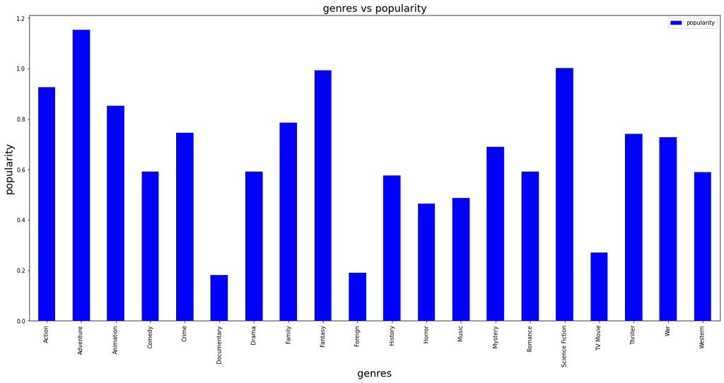

```python
# to get the most popular movie genres from year to year.
df_q1.groupby('genres')['popularity'].mean().plot(kind='bar',color='blue',figsize=(22,10));
plt.title('genres vs popularity', fontsize=18)
plt.xlabel('genres', fontsize=18)
plt.ylabel('popularity', fontsize=18)
plt.legend();
```

### Research Question 2 (What kinds of properties (i.e genre) are associated with movies that have high revenues)

```python
#Is there any correlation between adjsted budget and adjsted revenue?
df_q2=df_q.drop(['original_title','director', 'runtime', 'release_date', 'release_year', 'vote_count', 'vote_average', 'budget_adj', 'popularity',], axis=1)
df_q2
```

|  | genres | revenue_adj |
| --- | --- | --- |
| 0 | Action | 1.392446e+09 |
| 1 | Adventure | 1.392446e+09 |
| 2 | Science Fiction | 1.392446e+09 |
| 3 | Thriller | 1.392446e+09 |
| 4 | Action | 3.481613e+08 |
| ... | ... | ... |
| 26978 | Mystery | 0.000000e+00 |
| 26979 | Comedy | 0.000000e+00 |
| 26980 | Action | 0.000000e+00 |
| 26981 | Comedy | 0.000000e+00 |
| 26982 | Horror | 0.000000e+00 |

26983 rows × 2 columns

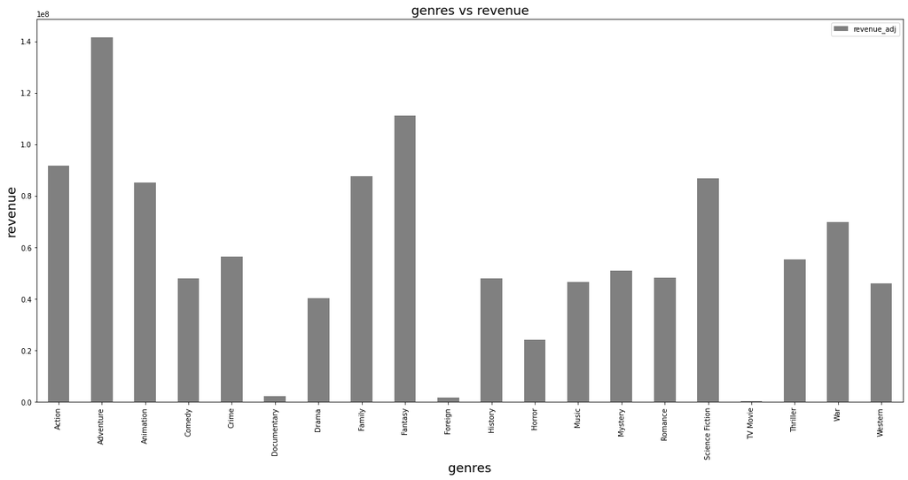

```python
#plot barchart of movie genres with revenue
df_q2.groupby('genres')['revenue_adj'].mean().plot(kind='bar',color='grey',figsize=(22,10));
plt.title('genres vs revenue', fontsize=18)
plt.xlabel('genres', fontsize=18)
plt.ylabel('revenue', fontsize=18)
plt.legend();
```

### Research Question 3 (Has the number of movies released increased overtime since 1960?)

```python
#create a table for vote_count, vote_average and release_year
df_q3=df_q.drop(['original_title','director', 'genres', 'runtime', 'release_date', 'revenue_adj', 'budget_adj', 'popularity',], axis=1)
df_q3
```

|  | vote_count | vote_average | release_year |
| --- | --- | --- | --- |
| 0 | 5562 | 6.5 | 2015 |
| 1 | 5562 | 6.5 | 2015 |
| 2 | 5562 | 6.5 | 2015 |
| 3 | 5562 | 6.5 | 2015 |
| 4 | 6185 | 7.1 | 2015 |
| ... | ... | ... | ... |
| 26978 | 11 | 6.5 | 1966 |
| 26979 | 11 | 6.5 | 1966 |
| 26980 | 22 | 5.4 | 1966 |
| 26981 | 22 | 5.4 | 1966 |
| 26982 | 15 | 1.5 | 1966 |

26983 rows × 3 columns

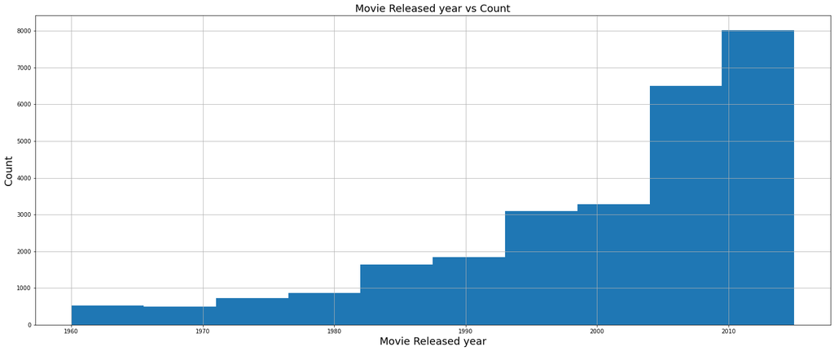

```python
#to get the increase in movies released since 1960 till date (2015)
df_q1.release_year.hist(figsize=(25,10))
plt.title('Movie Released year vs Count', fontsize=18)
plt.xlabel('Movie Released year', fontsize=18)
plt.ylabel('Count', fontsize=18)
```

The number of movies released increased overtime since 1960 till date

### Research Question 4 (Is there a correlation between Movies runtime and revenue)

```python
#create a table for runtime and revenue_adj
df_q4=df_q.drop(['original_title','director', 'genres', 'release_year', 'release_date', 'budget_adj', 'vote_count', 'vote_average', 'popularity',], axis=1)
df_q4
```

|  | runtime | revenue_adj |
| --- | --- | --- |
| 0 | 124 | 1.392446e+09 |
| 1 | 124 | 1.392446e+09 |
| 2 | 124 | 1.392446e+09 |
| 3 | 124 | 1.392446e+09 |
| 4 | 120 | 3.481613e+08 |
| ... | ... | ... |
| 26978 | 94 | 0.000000e+00 |
| 26979 | 94 | 0.000000e+00 |
| 26980 | 80 | 0.000000e+00 |
| 26981 | 80 | 0.000000e+00 |
| 26982 | 74 | 0.000000e+00 |

26983 rows × 2 columns

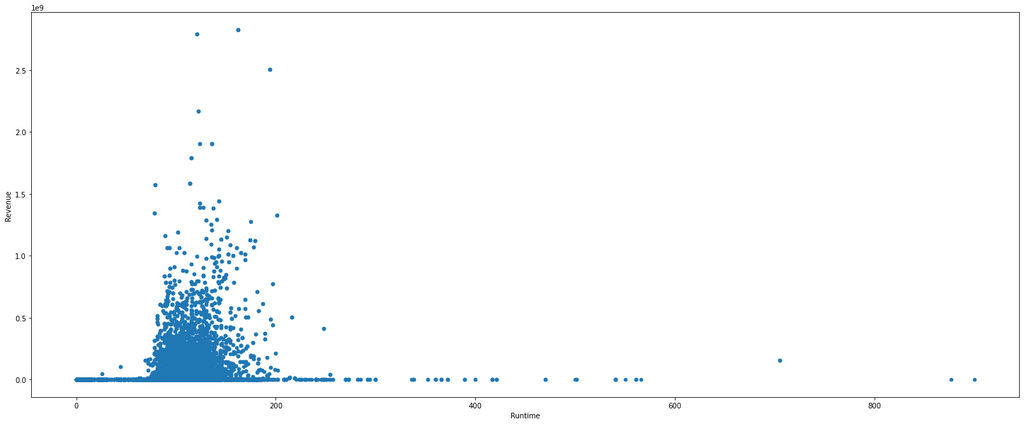

```python
### Is there a correlation between movie run time and revenue
df_q4['runtime'] = df_q4['runtime'].map(float)
df_q4.plot(x='runtime', y='revenue_adj', kind='scatter', xlabel='Runtime', ylabel='Revenue', figsize=(25,10))
```

There is no significant correlation between the Movie runtime and Revenue as some high revenue movies had lower runtime, and vice versa

## Conclusions

The number of movies released increased overtime since 1960 till date

There is no significant correlation between the Movie runtime and Revenue as some high revenue movies had lower runtime, and vice versa

A limitation of my exploration is the absence of actual number of viewers or individuals that rated the movies to accurately predict the correlation.

## References

# https://towardsdatascience.com/how-to-deal-with-missing-data-in-python-1f74a9112d93

# https://www.kaggle.com/general/244747

```python
from subprocess import call
call(['python', '-m', 'nbconvert', 'Investigate_a_Dataset.ipynb'])
```

```
4294967295
```